# Normalization performance report

- study: Methylation: Jaffe2018_age18_plate
- author: Chloe Yap
- date: 24 March, 2021

## Parameters used to test normalization

```
## $variables
## [1] "plate"       "Slide"       "sentrix_row" "sentrix_col" "Sex"
##
## $control.pcs
##  [1]  1  2  3  4  5  6  7  8  9 10
##
## $batch.pcs
##  [1]  1  2  3  4  5  6  7  8  9 10
##
## $batch.threshold
## [1] 0.01
##
## $colours
## NULL
```

## Control probe scree plots

The variance captured by each principal component.

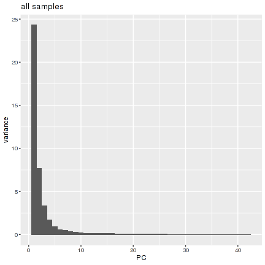

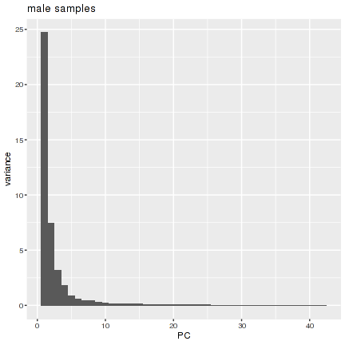

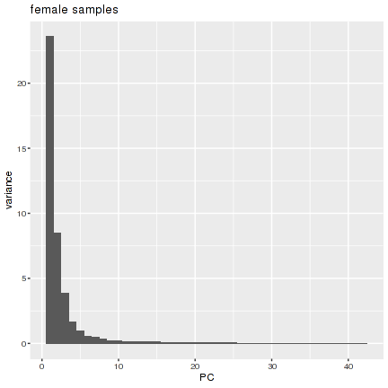

## Principal components of the control probes

The following plots show the first 3 principal components of the control matrix colored by batch variables. Batch variables with more than 10 levels are omitted.

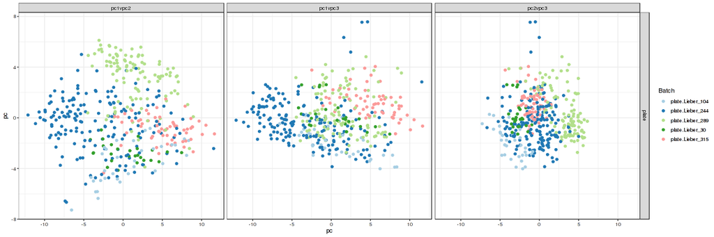

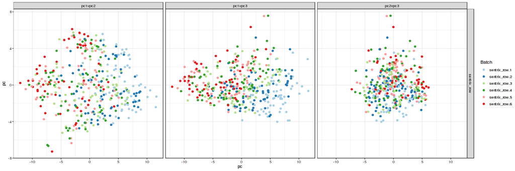

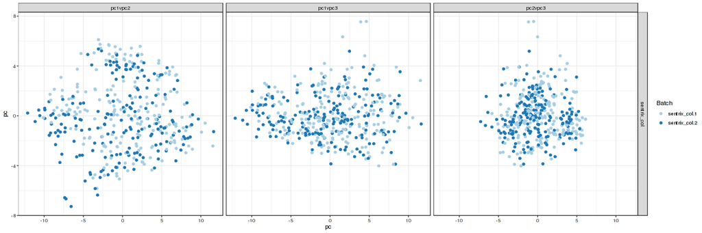

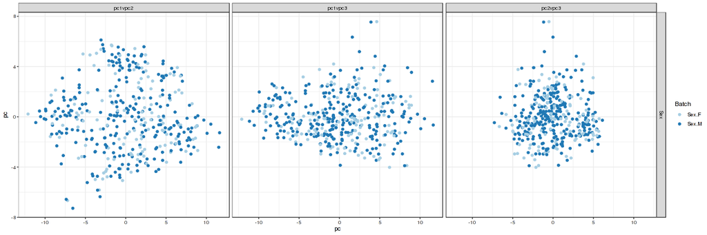

## Control probe associations with measured batch variables

Principal components of the control probes were regressed against batch variables. Shown are the \(-log_{10}\) p-values for these regressions. The horizontal dotted line denotes \(p = 0.05\) in log-scale.

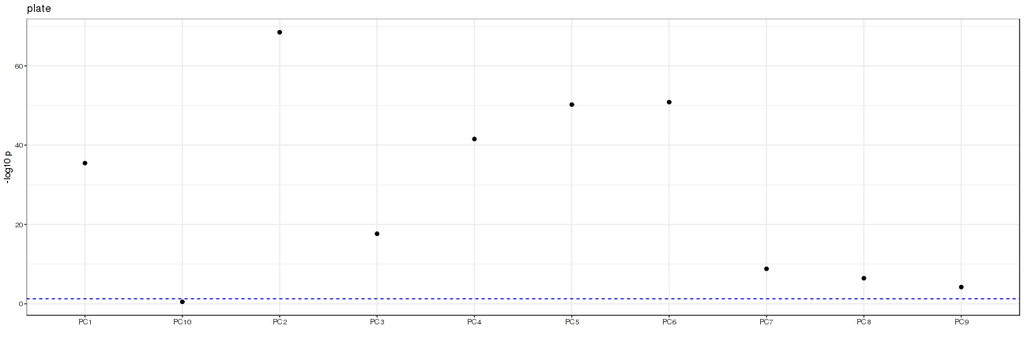

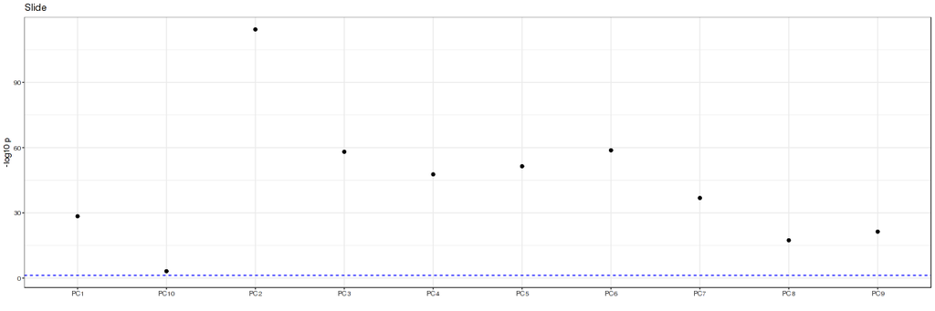

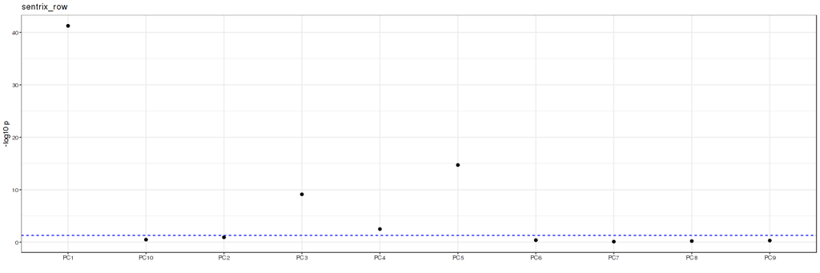

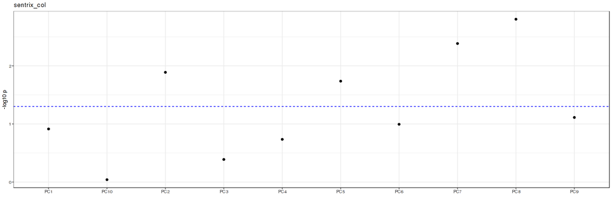

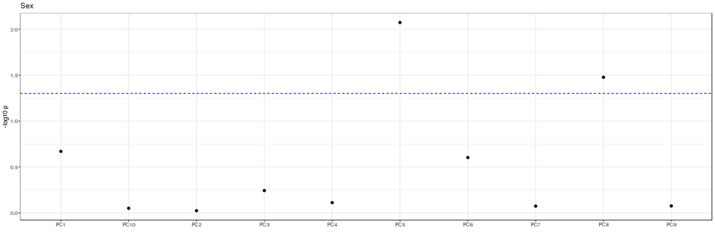

The following plots show regression coefficients when each principal component is regressed against each batch variable level along with 95% confidence intervals. Cases significantly different from zero are coloured red (p < 0.01, t-test).

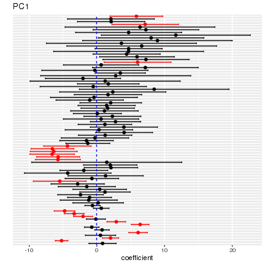

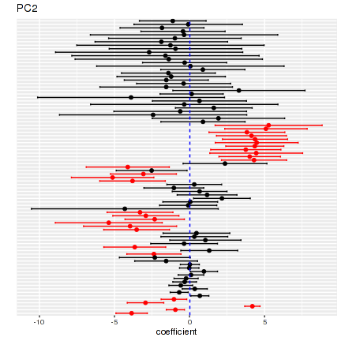

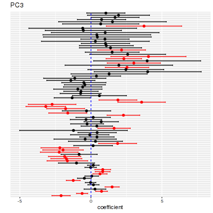

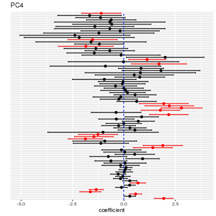

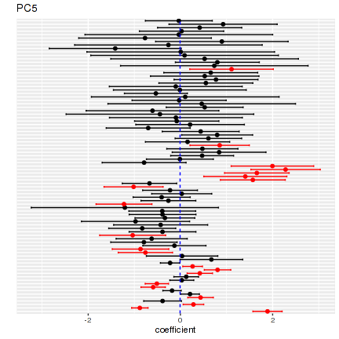

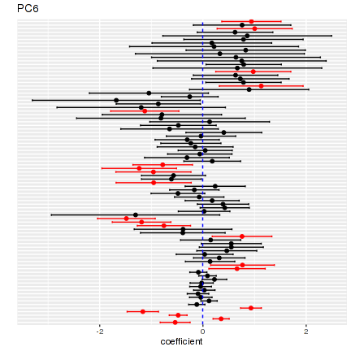

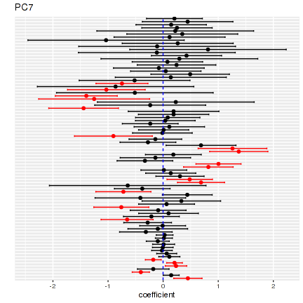

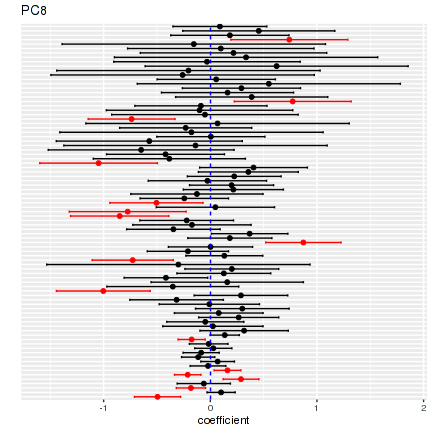

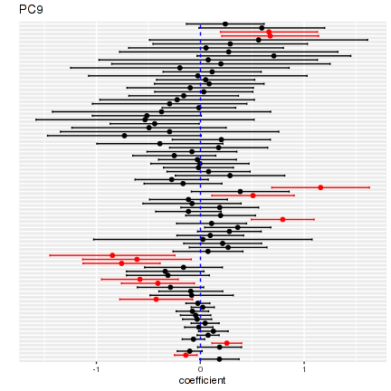

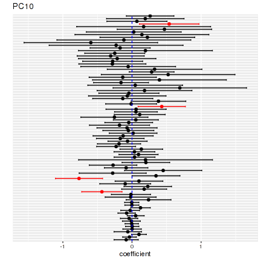

| batch.variable | batch.value | principal.component | test | p.value | estimate | lower | upper |
| --- | --- | --- | --- | --- | --- | --- | --- |
| plate |  | PC1 | F-test | 3.33e-36 | 53.749 |  |  |
| plate | Lieber_244 | PC1 | t-test | 7.59e-30 | -5.216 | -6.1457 | -4.2872 |
| plate | Lieber_289 | PC1 | t-test | 2.30e-04 | 2.017 | 0.8139 | 3.2206 |
| plate | Lieber_315 | PC1 | t-test | 7.50e-21 | 6.094 | 4.7219 | 7.4652 |
| Slide |  | PC1 | F-test | 3.69e-29 | 5.934 |  |  |
| Slide | 5815129027 | PC1 | t-test | 5.67e-03 | -4.355 | -7.8660 | -0.8440 |
| Slide | 5815129015 | PC1 | t-test | 4.61e-05 | -6.379 | -9.8508 | -2.9067 |
| Slide | 7927554093 | PC1 | t-test | 1.24e-03 | 7.133 | 2.2132 | 12.0519 |
| Slide | 5815129004 | PC1 | t-test | 1.19e-04 | -5.759 | -9.0806 | -2.4371 |
| Slide | 5815129018 | PC1 | t-test | 4.16e-06 | -6.576 | -9.7351 | -3.4174 |
| Slide | 7927554124 | PC1 | t-test | 8.58e-04 | 5.840 | 1.9402 | 9.7390 |
| Slide | 5815129009 | PC1 | t-test | 6.57e-05 | -5.721 | -8.9004 | -2.5411 |
| Slide | 5806484004 | PC1 | t-test | 1.74e-03 | -5.489 | -9.3944 | -1.5829 |
| Slide | 7810920075 | PC1 | t-test | 6.60e-03 | 6.010 | 1.0716 | 10.9479 |
| Slide | 5815129011 | PC1 | t-test | 9.08e-06 | -6.620 | -9.9214 | -3.3183 |
| sentrix_row |  | PC1 | F-test | 5.54e-42 | 52.863 |  |  |
| sentrix_row | 1 | PC1 | t-test | 1.19e-24 | 6.391 | 5.0921 | 7.6905 |
| sentrix_row | 4 | PC1 | t-test | 1.33e-03 | -2.048 | -3.4596 | -0.6361 |
| sentrix_row | 2 | PC1 | t-test | 4.92e-06 | 2.866 | 1.4876 | 4.2439 |
| sentrix_row | 6 | PC1 | t-test | 1.54e-11 | -4.774 | -6.3087 | -3.2393 |
| sentrix_row | 5 | PC1 | t-test | 5.91e-07 | -3.353 | -4.8269 | -1.8800 |
| plate |  | PC2 | F-test | 3.35e-69 | 125.519 |  |  |
| plate | Lieber_244 | PC2 | t-test | 7.03e-04 | -0.941 | -1.5470 | -0.3358 |
| plate | Lieber_289 | PC2 | t-test | 1.69e-54 | 4.188 | 3.6786 | 4.6977 |
| plate | Lieber_315 | PC2 | t-test | 6.97e-03 | -1.038 | -1.8917 | -0.1843 |
| plate | Lieber_104 | PC2 | t-test | 2.01e-15 | -3.858 | -4.9024 | -2.8145 |
| plate | Lieber_30 | PC2 | t-test | 1.19e-07 | -2.934 | -4.1520 | -1.7158 |
| Slide |  | PC2 | F-test | 4.57e-115 | 33.878 |  |  |
| Slide | 6229009069 | PC2 | t-test | 8.62e-06 | 4.364 | 2.1923 | 6.5351 |
| Slide | 5806484023 | PC2 | t-test | 7.68e-04 | -5.382 | -8.9452 | -1.8196 |

[output cut: 185 more lines]

## Principal components of the normalized betas

The following plots show the first 3 principal components of the most variable probes colored by batch variables. Batch variables with more than 10 levels are omitted.

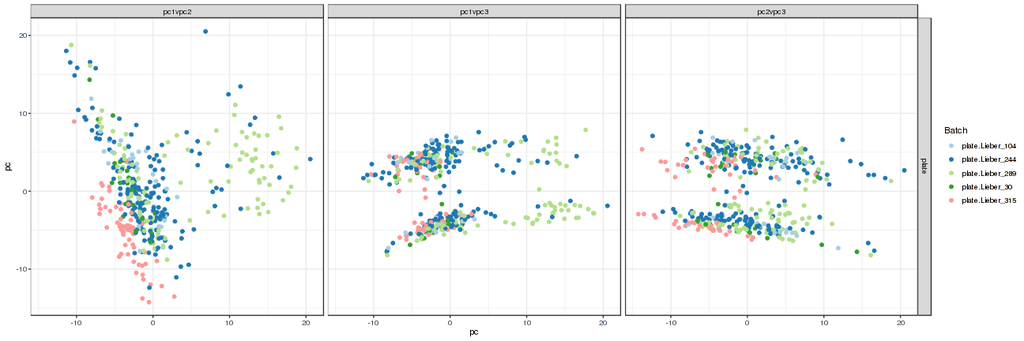

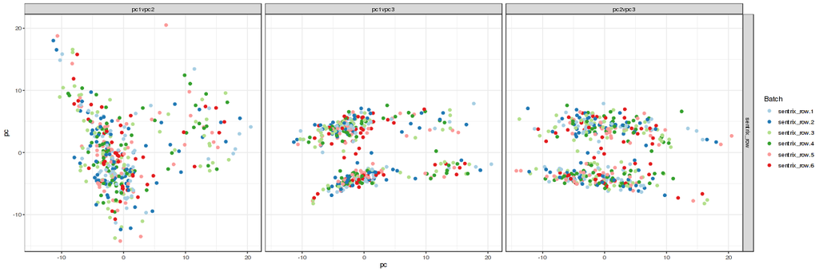

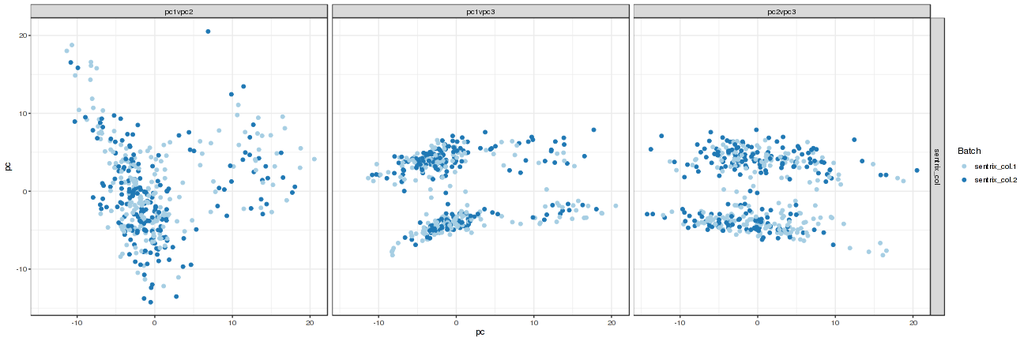

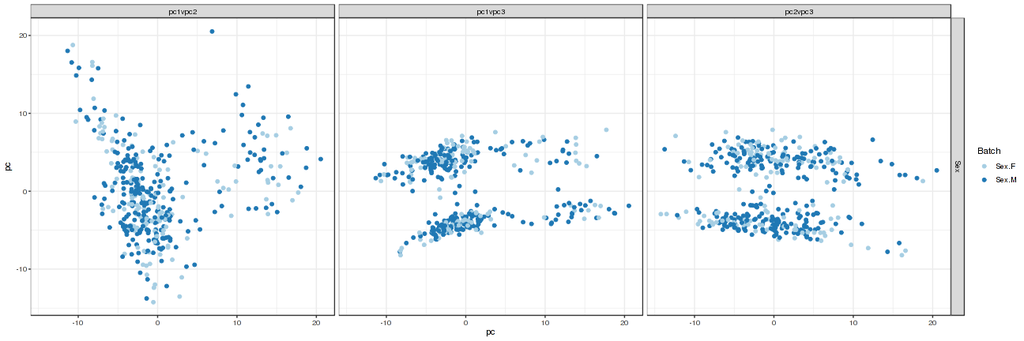